# DATA SCIENCE LATAM

UN ESPACIO PARA NUNCA PARAR DE APRENDER!!

Francisco Zambrano Cruz. Abril 2020.

[figure not shown]

# Data transformation con dplyr de Tidyverse

A menudo necesitará crear algunas variables, resumir informacion, cambiar el nombre de las variables o reordenar las observaciones para que los datos sean un poco más fáciles de trabajar. A continuación se aplicará cómo transformar sus datos utilizando el paquete **dplyr** de tidyverse con el conjunto de datos **flights** de la ciudad de Nueva York en 2013.

```r
#Cargamos Librerias

library(tidyverse)
#install.packages("nycflights13")
library(nycflights13)
```

```r
##Cargamos el data set flights

head(nycflights13::flights)
```

| year | month | day | dep_time | sched_dep_time | dep_delay | arr_time | sched_arr_time | arr_delay | carrier | flight | tailnum | origin | dest | air_time | distance | hour | minute | time_hour |
| --- | --- | --- | --- | --- | --- | --- | --- | --- | --- | --- | --- | --- | --- | --- | --- | --- | --- | --- |
| 2013 | 1 | 1 | 517 | 515 | 2 | 830 | 819 | 11 | UA | 1545 | N14228 | EWR | IAH | 227 | 1400 | 5 | 15 | 2013-01-01 05:00:00 |
| 2013 | 1 | 1 | 533 | 529 | 4 | 850 | 830 | 20 | UA | 1714 | N24211 | LGA | IAH | 227 | 1416 | 5 | 29 | 2013-01-01 05:00:00 |
| 2013 | 1 | 1 | 542 | 540 | 2 | 923 | 850 | 33 | AA | 1141 | N619AA | JFK | MIA | 160 | 1089 | 5 | 40 | 2013-01-01 05:00:00 |
| 2013 | 1 | 1 | 544 | 545 | -1 | 1004 | 1022 | -18 | B6 | 725 | N804JB | JFK | BQN | 183 | 1576 | 5 | 45 | 2013-01-01 05:00:00 |
| 2013 | 1 | 1 | 554 | 600 | -6 | 812 | 837 | -25 | DL | 461 | N668DN | LGA | ATL | 116 | 762 | 6 | 0 | 2013-01-01 06:00:00 |
| 2013 | 1 | 1 | 554 | 558 | -4 | 740 | 728 | 12 | UA | 1696 | N39463 | EWR | ORD | 150 | 719 | 5 | 58 | 2013-01-01 05:00:00 |

```r
#vistazo de los ultimos datos

tail(nycflights13::flights)
```

| year | month | day | dep_time | sched_dep_time | dep_delay | arr_time | sched_arr_time | arr_delay | carrier | flight | tailnum | origin | dest | air_time | distance | hour | minute | time_hour |
| --- | --- | --- | --- | --- | --- | --- | --- | --- | --- | --- | --- | --- | --- | --- | --- | --- | --- | --- |
| 2013 | 9 | 30 | NA | 1842 | NA | NA | 2019 | NA | EV | 5274 | N740EV | LGA | BNA | NA | 764 | 18 | 42 | 2013-09-30 18:00:00 |
| 2013 | 9 | 30 | NA | 1455 | NA | NA | 1634 | NA | 9E | 3393 | NA | JFK | DCA | NA | 213 | 14 | 55 | 2013-09-30 14:00:00 |
| 2013 | 9 | 30 | NA | 2200 | NA | NA | 2312 | NA | 9E | 3525 | NA | LGA | SYR | NA | 198 | 22 | 0 | 2013-09-30 22:00:00 |
| 2013 | 9 | 30 | NA | 1210 | NA | NA | 1330 | NA | MQ | 3461 | N535MQ | LGA | BNA | NA | 764 | 12 | 10 | 2013-09-30 12:00:00 |
| 2013 | 9 | 30 | NA | 1159 | NA | NA | 1344 | NA | MQ | 3572 | N511MQ | LGA | CLE | NA | 419 | 11 | 59 | 2013-09-30 11:00:00 |
| 2013 | 9 | 30 | NA | 840 | NA | NA | 1020 | NA | MQ | 3531 | N839MQ | LGA | RDU | NA | 431 | 8 | 40 | 2013-09-30 08:00:00 |

### Tipos de datos

- **int** = numeros enteros
- **dbl** = numeros reales (double)
- **chr** = vector de caracteres o strings
- **dttm** = date + time
- **lgl** = logical, booleanos (T o F)
- **fctr** = factor, variables categoricas
- **date** = fecha(dia, mes y año)

### Funciones de dplyr para manipular datos

Las cinco funciones clave de dplyr:

**`filter()`** <- filtrar observaciones a partor de valores concretos

**`arrange()`** <- reordenar las filas

**`select()`** <- selecccionar variables por sus nombre

**`mutate ()`** <- crea nuevas variables a partir de las exixtentes

**`summarise`** <- resumer valores

## FILTER ( FILTRAR )

El primer argumento es el data frame, el segundo argumento y los posteriores son las expresiones que filtran el data frame.

```r
#Filter con condicion tipo "and"

#Da otro dataframe sin alterar la base

head(filter(flights, month ==1 , day ==1 ))
```

| year | month | day | dep_time | sched_dep_time | dep_delay | arr_time | sched_arr_time | arr_delay | carrier | flight | tailnum | origin | dest | air_time | distance | hour | minute | time_hour |
| --- | --- | --- | --- | --- | --- | --- | --- | --- | --- | --- | --- | --- | --- | --- | --- | --- | --- | --- |
| 2013 | 1 | 1 | 517 | 515 | 2 | 830 | 819 | 11 | UA | 1545 | N14228 | EWR | IAH | 227 | 1400 | 5 | 15 | 2013-01-01 05:00:00 |
| 2013 | 1 | 1 | 533 | 529 | 4 | 850 | 830 | 20 | UA | 1714 | N24211 | LGA | IAH | 227 | 1416 | 5 | 29 | 2013-01-01 05:00:00 |
| 2013 | 1 | 1 | 542 | 540 | 2 | 923 | 850 | 33 | AA | 1141 | N619AA | JFK | MIA | 160 | 1089 | 5 | 40 | 2013-01-01 05:00:00 |
| 2013 | 1 | 1 | 544 | 545 | -1 | 1004 | 1022 | -18 | B6 | 725 | N804JB | JFK | BQN | 183 | 1576 | 5 | 45 | 2013-01-01 05:00:00 |
| 2013 | 1 | 1 | 554 | 600 | -6 | 812 | 837 | -25 | DL | 461 | N668DN | LGA | ATL | 116 | 762 | 6 | 0 | 2013-01-01 06:00:00 |
| 2013 | 1 | 1 | 554 | 558 | -4 | 740 | 728 | 12 | UA | 1696 | N39463 | EWR | ORD | 150 | 719 | 5 | 58 | 2013-01-01 05:00:00 |

```r
may19 <- filter(flights, month==5, day ==19)

head(may19)
```

| year | month | day | dep_time | sched_dep_time | dep_delay | arr_time | sched_arr_time | arr_delay | carrier | flight | tailnum | origin | dest | air_time | distance | hour | minute | time_hour |
| --- | --- | --- | --- | --- | --- | --- | --- | --- | --- | --- | --- | --- | --- | --- | --- | --- | --- | --- |
| 2013 | 5 | 19 | 2 | 2359 | 3 | 338 | 350 | -12 | B6 | 739 | N568JB | JFK | PSE | 198 | 1617 | 23 | 59 | 2013-05-19 23:00:00 |
| 2013 | 5 | 19 | 3 | 2040 | 203 | 111 | 2200 | 191 | MQ | 4449 | N844MQ | JFK | DCA | 48 | 213 | 20 | 40 | 2013-05-19 20:00:00 |
| 2013 | 5 | 19 | 15 | 2159 | 136 | 57 | 2302 | 115 | EV | 4276 | N11191 | EWR | BDL | 21 | 116 | 21 | 59 | 2013-05-19 21:00:00 |
| 2013 | 5 | 19 | 20 | 2050 | 210 | 152 | 2229 | 203 | EV | 5057 | N750EV | LGA | RIC | 62 | 292 | 20 | 50 | 2013-05-19 20:00:00 |
| 2013 | 5 | 19 | 37 | 2359 | 38 | 407 | 341 | 26 | B6 | 727 | N583JB | JFK | BQN | 192 | 1576 | 23 | 59 | 2013-05-19 23:00:00 |
| 2013 | 5 | 19 | 44 | 2225 | 139 | 148 | 2337 | 131 | EV | 5215 | N754EV | LGA | SYR | 42 | 198 | 22 | 25 | 2013-05-19 22:00:00 |

```r
# Filter con condicion tipo "or". Todos los vuelos que partieron en mayo o junio**

head( filter(flights, month==5 | month==6) )
```

| year | month | day | dep_time | sched_dep_time | dep_delay | arr_time | sched_arr_time | arr_delay | carrier | flight | tailnum | origin | dest | air_time | distance | hour | minute | time_hour |
| --- | --- | --- | --- | --- | --- | --- | --- | --- | --- | --- | --- | --- | --- | --- | --- | --- | --- | --- |
| 2013 | 5 | 1 | 9 | 1655 | 434 | 308 | 2020 | 408 | VX | 413 | N628VA | JFK | LAX | 341 | 2475 | 16 | 55 | 2013-05-01 16:00:00 |
| 2013 | 5 | 1 | 451 | 500 | -9 | 641 | 640 | 1 | US | 1219 | N196UW | EWR | CLT | 94 | 529 | 5 | 0 | 2013-05-01 05:00:00 |
| 2013 | 5 | 1 | 537 | 540 | -3 | 836 | 840 | -4 | AA | 701 | N5BYAA | JFK | MIA | 144 | 1089 | 5 | 40 | 2013-05-01 05:00:00 |
| 2013 | 5 | 1 | 544 | 545 | -1 | 818 | 827 | -9 | UA | 450 | N494UA | LGA | IAH | 190 | 1416 | 5 | 45 | 2013-05-01 05:00:00 |
| 2013 | 5 | 1 | 548 | 600 | -12 | 831 | 854 | -23 | B6 | 371 | N523JB | LGA | FLL | 140 | 1076 | 6 | 0 | 2013-05-01 06:00:00 |
| 2013 | 5 | 1 | 549 | 600 | -11 | 804 | 810 | -6 | MQ | 4650 | N520MQ | LGA | ATL | 113 | 762 | 6 | 0 | 2013-05-01 06:00:00 |

```r
# error comun => filter(flights, month==5 | 6)

# otra forma de codificar

head( filter(flights, month %in% c(5,6)) )
```

| year | month | day | dep_time | sched_dep_time | dep_delay | arr_time | sched_arr_time | arr_delay | carrier | flight | tailnum | origin | dest | air_time | distance | hour | minute | time_hour |
| --- | --- | --- | --- | --- | --- | --- | --- | --- | --- | --- | --- | --- | --- | --- | --- | --- | --- | --- |
| 2013 | 5 | 1 | 9 | 1655 | 434 | 308 | 2020 | 408 | VX | 413 | N628VA | JFK | LAX | 341 | 2475 | 16 | 55 | 2013-05-01 16:00:00 |
| 2013 | 5 | 1 | 451 | 500 | -9 | 641 | 640 | 1 | US | 1219 | N196UW | EWR | CLT | 94 | 529 | 5 | 0 | 2013-05-01 05:00:00 |
| 2013 | 5 | 1 | 537 | 540 | -3 | 836 | 840 | -4 | AA | 701 | N5BYAA | JFK | MIA | 144 | 1089 | 5 | 40 | 2013-05-01 05:00:00 |
| 2013 | 5 | 1 | 544 | 545 | -1 | 818 | 827 | -9 | UA | 450 | N494UA | LGA | IAH | 190 | 1416 | 5 | 45 | 2013-05-01 05:00:00 |
| 2013 | 5 | 1 | 548 | 600 | -12 | 831 | 854 | -23 | B6 | 371 | N523JB | LGA | FLL | 140 | 1076 | 6 | 0 | 2013-05-01 06:00:00 |
| 2013 | 5 | 1 | 549 | 600 | -11 | 804 | 810 | -6 | MQ | 4650 | N520MQ | LGA | ATL | 113 | 762 | 6 | 0 | 2013-05-01 06:00:00 |

```r
# Cálculo los retrasos en llegada como en salida

head ( filter(flights, !(arr_delay > 60 | dep_delay >60)) )
```

| year | month | day | dep_time | sched_dep_time | dep_delay | arr_time | sched_arr_time | arr_delay | carrier | flight | tailnum | origin | dest | air_time | distance | hour | minute | time_hour |
| --- | --- | --- | --- | --- | --- | --- | --- | --- | --- | --- | --- | --- | --- | --- | --- | --- | --- | --- |
| 2013 | 1 | 1 | 517 | 515 | 2 | 830 | 819 | 11 | UA | 1545 | N14228 | EWR | IAH | 227 | 1400 | 5 | 15 | 2013-01-01 05:00:00 |
| 2013 | 1 | 1 | 533 | 529 | 4 | 850 | 830 | 20 | UA | 1714 | N24211 | LGA | IAH | 227 | 1416 | 5 | 29 | 2013-01-01 05:00:00 |
| 2013 | 1 | 1 | 542 | 540 | 2 | 923 | 850 | 33 | AA | 1141 | N619AA | JFK | MIA | 160 | 1089 | 5 | 40 | 2013-01-01 05:00:00 |
| 2013 | 1 | 1 | 544 | 545 | -1 | 1004 | 1022 | -18 | B6 | 725 | N804JB | JFK | BQN | 183 | 1576 | 5 | 45 | 2013-01-01 05:00:00 |
| 2013 | 1 | 1 | 554 | 600 | -6 | 812 | 837 | -25 | DL | 461 | N668DN | LGA | ATL | 116 | 762 | 6 | 0 | 2013-01-01 06:00:00 |
| 2013 | 1 | 1 | 554 | 558 | -4 | 740 | 728 | 12 | UA | 1696 | N39463 | EWR | ORD | 150 | 719 | 5 | 58 | 2013-01-01 05:00:00 |

```r
#Tambien se puede codificar asi:

head ( filter(flights, arr_delay <=60, dep_delay <=60) )
```

| year | month | day | dep_time | sched_dep_time | dep_delay | arr_time | sched_arr_time | arr_delay | carrier | flight | tailnum | origin | dest | air_time | distance | hour | minute | time_hour |
| --- | --- | --- | --- | --- | --- | --- | --- | --- | --- | --- | --- | --- | --- | --- | --- | --- | --- | --- |
| 2013 | 1 | 1 | 517 | 515 | 2 | 830 | 819 | 11 | UA | 1545 | N14228 | EWR | IAH | 227 | 1400 | 5 | 15 | 2013-01-01 05:00:00 |
| 2013 | 1 | 1 | 533 | 529 | 4 | 850 | 830 | 20 | UA | 1714 | N24211 | LGA | IAH | 227 | 1416 | 5 | 29 | 2013-01-01 05:00:00 |
| 2013 | 1 | 1 | 542 | 540 | 2 | 923 | 850 | 33 | AA | 1141 | N619AA | JFK | MIA | 160 | 1089 | 5 | 40 | 2013-01-01 05:00:00 |
| 2013 | 1 | 1 | 544 | 545 | -1 | 1004 | 1022 | -18 | B6 | 725 | N804JB | JFK | BQN | 183 | 1576 | 5 | 45 | 2013-01-01 05:00:00 |
| 2013 | 1 | 1 | 554 | 600 | -6 | 812 | 837 | -25 | DL | 461 | N668DN | LGA | ATL | 116 | 762 | 6 | 0 | 2013-01-01 06:00:00 |
| 2013 | 1 | 1 | 554 | 558 | -4 | 740 | 728 | 12 | UA | 1696 | N39463 | EWR | ORD | 150 | 719 | 5 | 58 | 2013-01-01 05:00:00 |

```r
# filter para omitir NA

#se crea un tibble ficticio

(df <- tibble(x= c(1,2,NA, 4,5)))
```

| x |
| --- |
| 1 |
| 2 |
| NA |
| 4 |
| 5 |

```r
filter( df, x>2)
```

| x |
| --- |
| 4 |
| 5 |

```r
# filter para incluir NA is.na(df)

filter( df, is.na(df) | x>2)
```

| x |
| --- |
| NA |
| 4 |
| 5 |

## ARRANGE ( ORDENAR )

```r
#por defecto de menor a mayor (asc) menor a mayor

sorted_date <- arrange(flights, year, month, day)

head(sorted_date)
```

| year | month | day | dep_time | sched_dep_time | dep_delay | arr_time | sched_arr_time | arr_delay | carrier | flight | tailnum | origin | dest | air_time | distance | hour | minute | time_hour |
| --- | --- | --- | --- | --- | --- | --- | --- | --- | --- | --- | --- | --- | --- | --- | --- | --- | --- | --- |
| 2013 | 1 | 1 | 517 | 515 | 2 | 830 | 819 | 11 | UA | 1545 | N14228 | EWR | IAH | 227 | 1400 | 5 | 15 | 2013-01-01 05:00:00 |
| 2013 | 1 | 1 | 533 | 529 | 4 | 850 | 830 | 20 | UA | 1714 | N24211 | LGA | IAH | 227 | 1416 | 5 | 29 | 2013-01-01 05:00:00 |
| 2013 | 1 | 1 | 542 | 540 | 2 | 923 | 850 | 33 | AA | 1141 | N619AA | JFK | MIA | 160 | 1089 | 5 | 40 | 2013-01-01 05:00:00 |
| 2013 | 1 | 1 | 544 | 545 | -1 | 1004 | 1022 | -18 | B6 | 725 | N804JB | JFK | BQN | 183 | 1576 | 5 | 45 | 2013-01-01 05:00:00 |
| 2013 | 1 | 1 | 554 | 600 | -6 | 812 | 837 | -25 | DL | 461 | N668DN | LGA | ATL | 116 | 762 | 6 | 0 | 2013-01-01 06:00:00 |
| 2013 | 1 | 1 | 554 | 558 | -4 | 740 | 728 | 12 | UA | 1696 | N39463 | EWR | ORD | 150 | 719 | 5 | 58 | 2013-01-01 05:00:00 |

```r
#comprobacion

tail(sorted_date)
```

| year | month | day | dep_time | sched_dep_time | dep_delay | arr_time | sched_arr_time | arr_delay | carrier | flight | tailnum | origin | dest | air_time | distance | hour | minute | time_hour |
| --- | --- | --- | --- | --- | --- | --- | --- | --- | --- | --- | --- | --- | --- | --- | --- | --- | --- | --- |
| 2013 | 12 | 31 | NA | 855 | NA | NA | 1142 | NA | UA | 1506 | NA | EWR | JAC | NA | 1874 | 8 | 55 | 2013-12-31 08:00:00 |
| 2013 | 12 | 31 | NA | 705 | NA | NA | 931 | NA | UA | 1729 | NA | EWR | DEN | NA | 1605 | 7 | 5 | 2013-12-31 07:00:00 |
| 2013 | 12 | 31 | NA | 825 | NA | NA | 1029 | NA | US | 1831 | NA | JFK | CLT | NA | 541 | 8 | 25 | 2013-12-31 08:00:00 |
| 2013 | 12 | 31 | NA | 1615 | NA | NA | 1800 | NA | MQ | 3301 | N844MQ | LGA | RDU | NA | 431 | 16 | 15 | 2013-12-31 16:00:00 |
| 2013 | 12 | 31 | NA | 600 | NA | NA | 735 | NA | UA | 219 | NA | EWR | ORD | NA | 719 | 6 | 0 | 2013-12-31 06:00:00 |
| 2013 | 12 | 31 | NA | 830 | NA | NA | 1154 | NA | UA | 443 | NA | JFK | LAX | NA | 2475 | 8 | 30 | 2013-12-31 08:00:00 |

```r
#Ordenado descendente

head(arrange(flights, desc(arr_delay)))
```

| year | month | day | dep_time | sched_dep_time | dep_delay | arr_time | sched_arr_time | arr_delay | carrier | flight | tailnum | origin | dest | air_time | distance | hour | minute | time_hour |
| --- | --- | --- | --- | --- | --- | --- | --- | --- | --- | --- | --- | --- | --- | --- | --- | --- | --- | --- |
| 2013 | 1 | 9 | 641 | 900 | 1301 | 1242 | 1530 | 1272 | HA | 51 | N384HA | JFK | HNL | 640 | 4983 | 9 | 0 | 2013-01-09 09:00:00 |
| 2013 | 6 | 15 | 1432 | 1935 | 1137 | 1607 | 2120 | 1127 | MQ | 3535 | N504MQ | JFK | CMH | 74 | 483 | 19 | 35 | 2013-06-15 19:00:00 |
| 2013 | 1 | 10 | 1121 | 1635 | 1126 | 1239 | 1810 | 1109 | MQ | 3695 | N517MQ | EWR | ORD | 111 | 719 | 16 | 35 | 2013-01-10 16:00:00 |
| 2013 | 9 | 20 | 1139 | 1845 | 1014 | 1457 | 2210 | 1007 | AA | 177 | N338AA | JFK | SFO | 354 | 2586 | 18 | 45 | 2013-09-20 18:00:00 |
| 2013 | 7 | 22 | 845 | 1600 | 1005 | 1044 | 1815 | 989 | MQ | 3075 | N665MQ | JFK | CVG | 96 | 589 | 16 | 0 | 2013-07-22 16:00:00 |
| 2013 | 4 | 10 | 1100 | 1900 | 960 | 1342 | 2211 | 931 | DL | 2391 | N959DL | JFK | TPA | 139 | 1005 | 19 | 0 | 2013-04-10 19:00:00 |

```r
head(arrange(flights, desc(dep_delay)))
```

| year | month | day | dep_time | sched_dep_time | dep_delay | arr_time | sched_arr_time | arr_delay | carrier | flight | tailnum | origin | dest | air_time | distance | hour | minute | time_hour |
| --- | --- | --- | --- | --- | --- | --- | --- | --- | --- | --- | --- | --- | --- | --- | --- | --- | --- | --- |
| 2013 | 1 | 9 | 641 | 900 | 1301 | 1242 | 1530 | 1272 | HA | 51 | N384HA | JFK | HNL | 640 | 4983 | 9 | 0 | 2013-01-09 09:00:00 |
| 2013 | 6 | 15 | 1432 | 1935 | 1137 | 1607 | 2120 | 1127 | MQ | 3535 | N504MQ | JFK | CMH | 74 | 483 | 19 | 35 | 2013-06-15 19:00:00 |
| 2013 | 1 | 10 | 1121 | 1635 | 1126 | 1239 | 1810 | 1109 | MQ | 3695 | N517MQ | EWR | ORD | 111 | 719 | 16 | 35 | 2013-01-10 16:00:00 |
| 2013 | 9 | 20 | 1139 | 1845 | 1014 | 1457 | 2210 | 1007 | AA | 177 | N338AA | JFK | SFO | 354 | 2586 | 18 | 45 | 2013-09-20 18:00:00 |
| 2013 | 7 | 22 | 845 | 1600 | 1005 | 1044 | 1815 | 989 | MQ | 3075 | N665MQ | JFK | CVG | 96 | 589 | 16 | 0 | 2013-07-22 16:00:00 |
| 2013 | 4 | 10 | 1100 | 1900 | 960 | 1342 | 2211 | 931 | DL | 2391 | N959DL | JFK | TPA | 139 | 1005 | 19 | 0 | 2013-04-10 19:00:00 |

```r
#si hay NA en el data frame, el NA se van al final

arrange(df, x)
```

| x |
| --- |
| 1 |
| 2 |
| 4 |
| 5 |
| NA |

```r
arrange(df, desc(x))
```

| x |
| --- |
| 5 |
| 4 |
| 2 |
| 1 |
| NA |

## SELECT (SELECCIONAR COLUMNAS)

```r
head ( select(flights, year, month, day) )
```

| year | month | day |
| --- | --- | --- |
| 2013 | 1 | 1 |
| 2013 | 1 | 1 |
| 2013 | 1 | 1 |
| 2013 | 1 | 1 |
| 2013 | 1 | 1 |
| 2013 | 1 | 1 |

```r
# seleccionar desde - hasta..

head ( select(flights, year:day) )
```

| year | month | day |
| --- | --- | --- |
| 2013 | 1 | 1 |
| 2013 | 1 | 1 |
| 2013 | 1 | 1 |
| 2013 | 1 | 1 |
| 2013 | 1 | 1 |
| 2013 | 1 | 1 |

```r
head ( select(flights, dep_time:arr_delay) )
```

| dep_time | sched_dep_time | dep_delay | arr_time | sched_arr_time | arr_delay |
| --- | --- | --- | --- | --- | --- |
| 517 | 515 | 2 | 830 | 819 | 11 |
| 533 | 529 | 4 | 850 | 830 | 20 |
| 542 | 540 | 2 | 923 | 850 | 33 |
| 544 | 545 | -1 | 1004 | 1022 | -18 |
| 554 | 600 | -6 | 812 | 837 | -25 |
| 554 | 558 | -4 | 740 | 728 | 12 |

```r
sorted_date <- arrange(flights, year, month, day)

#extraemos un grupo de filas
head(sorted_date[1024:1068, ] )
```

| year | month | day | dep_time | sched_dep_time | dep_delay | arr_time | sched_arr_time | arr_delay | carrier | flight | tailnum | origin | dest | air_time | distance | hour | minute | time_hour |
| --- | --- | --- | --- | --- | --- | --- | --- | --- | --- | --- | --- | --- | --- | --- | --- | --- | --- | --- |
| 2013 | 1 | 2 | 827 | 835 | -8 | 1120 | 1102 | 18 | F9 | 835 | N211FR | LGA | DEN | 239 | 1620 | 8 | 35 | 2013-01-02 08:00:00 |
| 2013 | 1 | 2 | 827 | 820 | 7 | 1315 | 1329 | -14 | DL | 301 | N670DN | JFK | SJU | 188 | 1598 | 8 | 20 | 2013-01-02 08:00:00 |
| 2013 | 1 | 2 | 827 | 835 | -8 | 1059 | 1105 | -6 | MQ | 4610 | N0EGMQ | LGA | ATL | 124 | 762 | 8 | 35 | 2013-01-02 08:00:00 |
| 2013 | 1 | 2 | 828 | 830 | -2 | 947 | 950 | -3 | EV | 3845 | N14998 | EWR | ORF | 61 | 284 | 8 | 30 | 2013-01-02 08:00:00 |
| 2013 | 1 | 2 | 828 | 835 | -7 | 952 | 1007 | -15 | 9E | 3383 | N901XJ | JFK | DCA | 42 | 213 | 8 | 35 | 2013-01-02 08:00:00 |
| 2013 | 1 | 2 | 828 | 830 | -2 | 1021 | 1012 | 9 | B6 | 905 | N281JB | JFK | ORD | 138 | 740 | 8 | 30 | 2013-01-02 08:00:00 |

```r
head ( select(sorted_date[1024:1068,], dep_delay, arr_delay) )
```

| dep_delay | arr_delay |
| --- | --- |
| -8 | 18 |
| 7 | -14 |
| -8 | -6 |
| -2 | -3 |
| -7 | -15 |
| -2 | 9 |

```r
#seleccionar campos exceptuendo un grupo

head ( select(flights, -(year:day)) )
```

| dep_time | sched_dep_time | dep_delay | arr_time | sched_arr_time | arr_delay | carrier | flight | tailnum | origin | dest | air_time | distance | hour | minute | time_hour |
| --- | --- | --- | --- | --- | --- | --- | --- | --- | --- | --- | --- | --- | --- | --- | --- |
| 517 | 515 | 2 | 830 | 819 | 11 | UA | 1545 | N14228 | EWR | IAH | 227 | 1400 | 5 | 15 | 2013-01-01 05:00:00 |
| 533 | 529 | 4 | 850 | 830 | 20 | UA | 1714 | N24211 | LGA | IAH | 227 | 1416 | 5 | 29 | 2013-01-01 05:00:00 |
| 542 | 540 | 2 | 923 | 850 | 33 | AA | 1141 | N619AA | JFK | MIA | 160 | 1089 | 5 | 40 | 2013-01-01 05:00:00 |
| 544 | 545 | -1 | 1004 | 1022 | -18 | B6 | 725 | N804JB | JFK | BQN | 183 | 1576 | 5 | 45 | 2013-01-01 05:00:00 |
| 554 | 600 | -6 | 812 | 837 | -25 | DL | 461 | N668DN | LGA | ATL | 116 | 762 | 6 | 0 | 2013-01-01 06:00:00 |
| 554 | 558 | -4 | 740 | 728 | 12 | UA | 1696 | N39463 | EWR | ORD | 150 | 719 | 5 | 58 | 2013-01-01 05:00:00 |

```r
#seleccionar campos que empiencen con "dep"

head ( select(flights, starts_with("dep")) )
```

| dep_time | dep_delay |
| --- | --- |
| 517 | 2 |
| 533 | 4 |
| 542 | 2 |
| 544 | -1 |
| 554 | -6 |
| 554 | -4 |

```r
#seleccionar campos que terminen con "delay"

head( select(flights, ends_with("delay")) )
```

| dep_delay | arr_delay |
| --- | --- |
| 2 | 11 |
| 4 | 20 |
| 2 | 33 |
| -1 | -18 |
| -6 | -25 |
| -4 | 12 |

```r
#seleccionar campos que contengan "st"

head ( select(flights, contains("st")))
```

| dest | distance |
| --- | --- |
| IAH | 1400 |
| IAH | 1416 |
| MIA | 1089 |
| BQN | 1576 |
| ATL | 762 |
| ORD | 719 |

```r
#seleccionar campos con expresiones regulares

head ( select(flights, matches("(.)\\1")) )
```

| arr_time | sched_arr_time | arr_delay | carrier |
| --- | --- | --- | --- |
| 830 | 819 | 11 | UA |
| 850 | 830 | 20 | UA |
| 923 | 850 | 33 | AA |
| 1004 | 1022 | -18 | B6 |
| 812 | 837 | -25 | DL |
| 740 | 728 | 12 | UA |

```r
#seleccionar campos en caso que no tengan cabecera

select(flights, num_range("x", 1:5))
```

# RENAME (RENOMBRAR Y REORDENAR VARIABLES )

```r
# se cambiará el nombre del campo dep_time con el nombre deptime del data set flights

head(rename(flights, deptime = dep_time))
```

| year | month | day | deptime | sched_dep_time | dep_delay | arr_time | sched_arr_time | arr_delay | carrier | flight | tailnum | origin | dest | air_time | distance | hour | minute | time_hour |
| --- | --- | --- | --- | --- | --- | --- | --- | --- | --- | --- | --- | --- | --- | --- | --- | --- | --- | --- |
| 2013 | 1 | 1 | 517 | 515 | 2 | 830 | 819 | 11 | UA | 1545 | N14228 | EWR | IAH | 227 | 1400 | 5 | 15 | 2013-01-01 05:00:00 |
| 2013 | 1 | 1 | 533 | 529 | 4 | 850 | 830 | 20 | UA | 1714 | N24211 | LGA | IAH | 227 | 1416 | 5 | 29 | 2013-01-01 05:00:00 |
| 2013 | 1 | 1 | 542 | 540 | 2 | 923 | 850 | 33 | AA | 1141 | N619AA | JFK | MIA | 160 | 1089 | 5 | 40 | 2013-01-01 05:00:00 |
| 2013 | 1 | 1 | 544 | 545 | -1 | 1004 | 1022 | -18 | B6 | 725 | N804JB | JFK | BQN | 183 | 1576 | 5 | 45 | 2013-01-01 05:00:00 |
| 2013 | 1 | 1 | 554 | 600 | -6 | 812 | 837 | -25 | DL | 461 | N668DN | LGA | ATL | 116 | 762 | 6 | 0 | 2013-01-01 06:00:00 |
| 2013 | 1 | 1 | 554 | 558 | -4 | 740 | 728 | 12 | UA | 1696 | N39463 | EWR | ORD | 150 | 719 | 5 | 58 | 2013-01-01 05:00:00 |

```r
#tambien se puede renombrar con select

head (select(flights, deptime = dep_time))
```

| deptime |
| --- |
| 517 |
| 533 |
| 542 |
| 544 |
| 554 |
| 554 |

```r
#reordenar ciertos campos para verlos al inicio, y con everything() el resto

head ( select(flights, time_hour, distance, air_time, everything()) )
```

| time_hour | distance | air_time | year | month | day | dep_time | sched_dep_time | dep_delay | arr_time | sched_arr_time | arr_delay | carrier | flight | tailnum | origin | dest | hour | minute |
| --- | --- | --- | --- | --- | --- | --- | --- | --- | --- | --- | --- | --- | --- | --- | --- | --- | --- | --- |
| 2013-01-01 05:00:00 | 1400 | 227 | 2013 | 1 | 1 | 517 | 515 | 2 | 830 | 819 | 11 | UA | 1545 | N14228 | EWR | IAH | 5 | 15 |
| 2013-01-01 05:00:00 | 1416 | 227 | 2013 | 1 | 1 | 533 | 529 | 4 | 850 | 830 | 20 | UA | 1714 | N24211 | LGA | IAH | 5 | 29 |
| 2013-01-01 05:00:00 | 1089 | 160 | 2013 | 1 | 1 | 542 | 540 | 2 | 923 | 850 | 33 | AA | 1141 | N619AA | JFK | MIA | 5 | 40 |
| 2013-01-01 05:00:00 | 1576 | 183 | 2013 | 1 | 1 | 544 | 545 | -1 | 1004 | 1022 | -18 | B6 | 725 | N804JB | JFK | BQN | 5 | 45 |
| 2013-01-01 06:00:00 | 762 | 116 | 2013 | 1 | 1 | 554 | 600 | -6 | 812 | 837 | -25 | DL | 461 | N668DN | LGA | ATL | 6 | 0 |
| 2013-01-01 05:00:00 | 719 | 150 | 2013 | 1 | 1 | 554 | 558 | -4 | 740 | 728 | 12 | UA | 1696 | N39463 | EWR | ORD | 5 | 58 |

# MUTATE ( CREAR NUEVAS COLUMNAS )

```r
#Primero vamos a crear un data set pequeño

flights_new <- select(flights,
                      year:day,
                      ends_with("delay"),
                      distance,
                      air_time)

head(flights_new)
```

| year | month | day | dep_delay | arr_delay | distance | air_time |
| --- | --- | --- | --- | --- | --- | --- |
| 2013 | 1 | 1 | 2 | 11 | 1400 | 227 |
| 2013 | 1 | 1 | 4 | 20 | 1416 | 227 |
| 2013 | 1 | 1 | 2 | 33 | 1089 | 160 |
| 2013 | 1 | 1 | -1 | -18 | 1576 | 183 |
| 2013 | 1 | 1 | -6 | -25 | 762 | 116 |
| 2013 | 1 | 1 | -4 | 12 | 719 | 150 |

```r
#Creamos nuevas columnas con mutate, para no dañar flights_new creamos un data set temporal

temp = mutate(flights_new,
           time_gain = arr_delay - dep_delay, #diff_t (min) tiempo ganado
           flights_speed = distance/(air_time/60), #V= d/t (km/h)
           air_time_hour = air_time/60,
           time_gain_per_hour = time_gain / air_time_hour
       )

head(temp)
```

| year | month | day | dep_delay | arr_delay | distance | air_time | time_gain | flights_speed | air_time_hour | time_gain_per_hour |
| --- | --- | --- | --- | --- | --- | --- | --- | --- | --- | --- |
| 2013 | 1 | 1 | 2 | 11 | 1400 | 227 | 9 | 370.0441 | 3.783333 | 2.378855 |
| 2013 | 1 | 1 | 4 | 20 | 1416 | 227 | 16 | 374.2731 | 3.783333 | 4.229075 |
| 2013 | 1 | 1 | 2 | 33 | 1089 | 160 | 31 | 408.3750 | 2.666667 | 11.625000 |
| 2013 | 1 | 1 | -1 | -18 | 1576 | 183 | -17 | 516.7213 | 3.050000 | -5.573770 |
| 2013 | 1 | 1 | -6 | -25 | 762 | 116 | -19 | 394.1379 | 1.933333 | -9.827586 |
| 2013 | 1 | 1 | -4 | 12 | 719 | 150 | 16 | 287.6000 | 2.500000 | 6.400000 |

```r
#para asiganarle los nuevos campos a flights_news, se sobreescribe los nuevos campos

mutate(flights_new,
       time_gain = arr_delay - dep_delay, #diff_t (min) tiempo ganado
       flights_speed = distance/(air_time/60), #V= d/t (km/h)
       air_time_hour = air_time/60,
       time_gain_per_hour = time_gain / air_time_hour
) -> flights_new

head(flights_new)
```

| year | month | day | dep_delay | arr_delay | distance | air_time | time_gain | flights_speed | air_time_hour | time_gain_per_hour |
| --- | --- | --- | --- | --- | --- | --- | --- | --- | --- | --- |
| 2013 | 1 | 1 | 2 | 11 | 1400 | 227 | 9 | 370.0441 | 3.783333 | 2.378855 |
| 2013 | 1 | 1 | 4 | 20 | 1416 | 227 | 16 | 374.2731 | 3.783333 | 4.229075 |
| 2013 | 1 | 1 | 2 | 33 | 1089 | 160 | 31 | 408.3750 | 2.666667 | 11.625000 |
| 2013 | 1 | 1 | -1 | -18 | 1576 | 183 | -17 | 516.7213 | 3.050000 | -5.573770 |
| 2013 | 1 | 1 | -6 | -25 | 762 | 116 | -19 | 394.1379 | 1.933333 | -9.827586 |
| 2013 | 1 | 1 | -4 | 12 | 719 | 150 | 16 | 287.6000 | 2.500000 | 6.400000 |

```r
#transmutate para solo tener los nuevos campos

temp = transmute(flights_new,
           time_gain = arr_delay - dep_delay, #diff_t (min) tiempo ganado
           flights_speed = distance/(air_time/60), #V= d/t (km/h)
           air_time_hour = air_time/60,
           time_gain_per_hour = time_gain / air_time_hour
)

head(temp)
```

| time_gain | flights_speed | air_time_hour | time_gain_per_hour |
| --- | --- | --- | --- |
| 9 | 370.0441 | 3.783333 | 2.378855 |
| 16 | 374.2731 | 3.783333 | 4.229075 |
| 31 | 408.3750 | 2.666667 | 11.625000 |
| -17 | 516.7213 | 3.050000 | -5.573770 |
| -19 | 394.1379 | 1.933333 | -9.827586 |
| 16 | 287.6000 | 2.500000 | 6.400000 |

```r
#para asignar estas nuevas variables a otro data frame

transmute(flights_new,
          time_gain = arr_delay - dep_delay, #diff_t (min) tiempo ganado
          flights_speed = distance/(air_time/60), #V= d/t (km/h)
          air_time_hour = air_time/60,
          time_gain_per_hour = time_gain / air_time_hour
)-> data_from_flights

head(data_from_flights)
```

| time_gain | flights_speed | air_time_hour | time_gain_per_hour |
| --- | --- | --- | --- |
| 9 | 370.0441 | 3.783333 | 2.378855 |
| 16 | 374.2731 | 3.783333 | 4.229075 |
| 31 | 408.3750 | 2.666667 | 11.625000 |
| -17 | 516.7213 | 3.050000 | -5.573770 |
| -19 | 394.1379 | 1.933333 | -9.827586 |
| 16 | 287.6000 | 2.500000 | 6.400000 |

### Funciones adicionales para usar con mutate

```r
#operaciones en mutate ***************************

#agregado de funciones

# x/sum(x) = proporcion sobre el total
# x - mean(x) = distancia respecto a la media
# (x - mean(x))/ sd(x) = normalizacion
# (x - min(x))/(max(x)-min(x)) = escalado entre 0 1 (estandarizar)


##aritmetica modular

# %/% = cociente division entera
# %% = resto division entera
# x== y*(x%/%y)+(x%%y)
```

```r
head (transmute(flights,
          air_time,
          hour_air = air_time %/% 60,
          minute_air = air_time %% 60))
```

| air_time | hour_air | minute_air |
| --- | --- | --- |
| 227 | 3 | 47 |
| 227 | 3 | 47 |
| 160 | 2 | 40 |
| 183 | 3 | 3 |
| 116 | 1 | 56 |
| 150 | 2 | 30 |

**Funciones offsets**

```r
#offsets: lead()mueve a la izq, lag() mueve a la derecha
```

```r
df= 1:12
df
```

1. 1

2. 2

3. 3

4. 4

5. 5

6. 6

7. 7

8. 8

9. 9

10. 10

11. 11

12. 12

```r
lag(df)
```

1. <NA>

2. 1

3. 2

4. 3

5. 4

6. 5

7. 6

8. 7

9. 8

10. 9

11. 10

12. 11

```r
lead(df)
```

1. 2

2. 3

3. 4

4. 5

5. 6

6. 7

7. 8

8. 9

9. 10

10. 11

11. 12

12. <NA>

**funciones acumulativas**

cumsum(), cumprod(), cummin(), cummax() -> funciones basicas del stats

cummean() del paquete dplyr medias agrupadas

```r
df
cumsum(df) #acumulado
```

1. 1

2. 2

3. 3

4. 4

5. 5

6. 6

7. 7

8. 8

9. 9

10. 10

11. 11

12. 12

1. 1

2. 3

3. 6

4. 10

5. 15

6. 21

7. 28

8. 36

9. 45

10. 55

11. 66

12. 78

```r
mutate(flights_new,
       acum_arr_delay = cumsum(flights_new$arr_delay)
) -> temp

head(temp)
```

| year | month | day | dep_delay | arr_delay | distance | air_time | time_gain | flights_speed | air_time_hour | time_gain_per_hour | acum_arr_delay |
| --- | --- | --- | --- | --- | --- | --- | --- | --- | --- | --- | --- |
| 2013 | 1 | 1 | 2 | 11 | 1400 | 227 | 9 | 370.0441 | 3.783333 | 2.378855 | 11 |
| 2013 | 1 | 1 | 4 | 20 | 1416 | 227 | 16 | 374.2731 | 3.783333 | 4.229075 | 31 |
| 2013 | 1 | 1 | 2 | 33 | 1089 | 160 | 31 | 408.3750 | 2.666667 | 11.625000 | 64 |
| 2013 | 1 | 1 | -1 | -18 | 1576 | 183 | -17 | 516.7213 | 3.050000 | -5.573770 | 46 |
| 2013 | 1 | 1 | -6 | -25 | 762 | 116 | -19 | 394.1379 | 1.933333 | -9.827586 | 21 |
| 2013 | 1 | 1 | -4 | 12 | 719 | 150 | 16 | 287.6000 | 2.500000 | 6.400000 | 33 |

```r
df
cumprod(df) #multiplica con los anteriores
```

1. 1

2. 2

3. 3

4. 4

5. 5

6. 6

7. 7

8. 8

9. 9

10. 10

11. 11

12. 12

1. 1

2. 2

3. 6

4. 24

5. 120

6. 720

7. 5040

8. 40320

9. 362880

10. 3628800

11. 39916800

12. 479001600

```r
df
cummin(df) #se queda con el minimo
```

1. 1

2. 2

3. 3

4. 4

5. 5

6. 6

7. 7

8. 8

9. 9

10. 10

11. 11

12. 12

1. 1

2. 1

3. 1

4. 1

5. 1

6. 1

7. 1

8. 1

9. 1

10. 1

11. 1

12. 1

```r
df = c(1, 5, 13, 20, 4)
cummax(df) #acumula hasta el maximo
```

1. 1

2. 5

3. 13

4. 20

5. 20

```r
df= 1:12
cummean(df) #cacula media hasta el valor n-actual
```

1. 1

2. 1.5

3. 2

4. 2.5

5. 3

6. 3.5

7. 4

8. 4.5

9. 5

10. 5.5

11. 6

12. 6.5

**comparaciones logicas >, < , >=, <= !=**

```r
head ( transmute(flights, dep_delay,
          has_been_delayed = (dep_delay > 0)) )
```

| dep_delay | has_been_delayed |
| --- | --- |
| 2 | TRUE |
| 4 | TRUE |
| 2 | TRUE |
| -1 | FALSE |
| -6 | FALSE |
| -4 | FALSE |

**rankings: min_rank()**

```r
df <- c(7,1,2,5,3,3,8,NA,3,4,-2)
df
```

1. 7

2. 1

3. 2

4. 5

5. 3

6. 3

7. 8

8. <NA>

9. 3

10. 4

11. -2

```r
df
min_rank(df) #el menor valor toma el valor 1 (de un orden asc)
```

1. 7

2. 1

3. 2

4. 5

5. 3

6. 3

7. 8

8. <NA>

9. 3

10. 4

11. -2

1. 9

2. 2

3. 3

4. 8

5. 4

6. 4

7. 10

8. <NA>

9. 4

10. 7

11. 1

```r
df
min_rank(desc(df)) #el mayor valor toma el valor de 1 (de un ord desc)
```

1. 7

2. 1

3. 2

4. 5

5. 3

6. 3

7. 8

8. <NA>

9. 3

10. 4

11. -2

1. 2

2. 9

3. 8

4. 3

5. 5

6. 5

7. 1

8. <NA>

9. 5

10. 4

11. 10

**Posiciones sin repeticiones: row_number**

```r
df
row_number(df)
```

1. 7

2. 1

3. 2

4. 5

5. 3

6. 3

7. 8

8. <NA>

9. 3

10. 4

11. -2

1. 9

2. 2

3. 3

4. 8

5. 4

6. 5

7. 10

8. <NA>

9. 6

10. 7

11. 1

```r
head ( mutate(flights_new, row_n = row_number(air_time)) %>%
    arrange(air_time)
      )
```

| year | month | day | dep_delay | arr_delay | distance | air_time | time_gain | flights_speed | air_time_hour | time_gain_per_hour | row_n |
| --- | --- | --- | --- | --- | --- | --- | --- | --- | --- | --- | --- |
| 2013 | 1 | 16 | 40 | 31 | 116 | 20 | -9 | 348.0000 | 0.3333333 | -27.000000 | 1 |
| 2013 | 4 | 13 | 10 | -6 | 116 | 20 | -16 | 348.0000 | 0.3333333 | -48.000000 | 2 |
| 2013 | 12 | 6 | 31 | 27 | 116 | 21 | -4 | 331.4286 | 0.3500000 | -11.428571 | 3 |
| 2013 | 2 | 3 | 24 | 23 | 80 | 21 | -1 | 228.5714 | 0.3500000 | -2.857143 | 4 |
| 2013 | 2 | 5 | -12 | -29 | 116 | 21 | -17 | 331.4286 | 0.3500000 | -48.571429 | 5 |
| 2013 | 2 | 12 | -7 | -14 | 80 | 21 | -7 | 228.5714 | 0.3500000 | -20.000000 | 6 |

**Posiciones con repeticiones: dense_rank**

```r
df
dense_rank(df)
```

1. 7

2. 1

3. 2

4. 5

5. 3

6. 3

7. 8

8. <NA>

9. 3

10. 4

11. -2

1. 7

2. 2

3. 3

4. 6

5. 4

6. 4

7. 8

8. <NA>

9. 4

10. 5

11. 1

```r
head ( mutate(flights_new, dense = dense_rank(air_time)) %>%
    arrange(air_time)
      )
```

| year | month | day | dep_delay | arr_delay | distance | air_time | time_gain | flights_speed | air_time_hour | time_gain_per_hour | dense |
| --- | --- | --- | --- | --- | --- | --- | --- | --- | --- | --- | --- |
| 2013 | 1 | 16 | 40 | 31 | 116 | 20 | -9 | 348.0000 | 0.3333333 | -27.000000 | 1 |
| 2013 | 4 | 13 | 10 | -6 | 116 | 20 | -16 | 348.0000 | 0.3333333 | -48.000000 | 1 |
| 2013 | 12 | 6 | 31 | 27 | 116 | 21 | -4 | 331.4286 | 0.3500000 | -11.428571 | 2 |
| 2013 | 2 | 3 | 24 | 23 | 80 | 21 | -1 | 228.5714 | 0.3500000 | -2.857143 | 2 |
| 2013 | 2 | 5 | -12 | -29 | 116 | 21 | -17 | 331.4286 | 0.3500000 | -48.571429 | 2 |
| 2013 | 2 | 12 | -7 | -14 | 80 | 21 | -7 | 228.5714 | 0.3500000 | -20.000000 | 2 |

```r
df
percent_rank(df)
```

1. 7

2. 1

3. 2

4. 5

5. 3

6. 3

7. 8

8. <NA>

9. 3

10. 4

11. -2

1. 0.888888888888889

2. 0.111111111111111

3. 0.222222222222222

4. 0.777777777777778

5. 0.333333333333333

6. 0.333333333333333

7. 1

8. <NA>

9. 0.333333333333333

10. 0.666666666666667

11. 0

```r
df
cume_dist(df)
```

1. 7

2. 1

3. 2

4. 5

5. 3

6. 3

7. 8

8. <NA>

9. 3

10. 4

11. -2

1. 0.9

2. 0.2

3. 0.3

4. 0.8

5. 0.6

6. 0.6

7. 1

8. <NA>

9. 0.6

10. 0.7

11. 0.1

```r
#para saber que cuantil pertenece cada valor, repartido en 4 cuantiles
df
ntile(df,4)
```

1. 7

2. 1

3. 2

4. 5

5. 3

6. 3

7. 8

8. <NA>

9. 3

10. 4

11. -2

1. 4

2. 1

3. 1

4. 3

5. 2

6. 2

7. 4

8. <NA>

9. 3

10. 3

11. 1

## SUMMARISE

```r
#resume sobre toda la base
summarise(flights, delay= mean(dep_delay, na.rm = T))
```

| delay |
| --- |
| 12.63907 |

### Uso de group_by con summarise

```r
#Resumen por año y mes. Usamos la funcion group_by para agrupar.

by_month_group <- group_by(flights, year, month)

summarise(by_month_group, delay = mean(dep_delay, na.rm=T))
```

| year | month | delay |
| --- | --- | --- |
| 2013 | 1 | 10.036665 |
| 2013 | 2 | 10.816843 |
| 2013 | 3 | 13.227076 |
| 2013 | 4 | 13.938038 |
| 2013 | 5 | 12.986859 |
| 2013 | 6 | 20.846332 |
| 2013 | 7 | 21.727787 |
| 2013 | 8 | 12.611040 |
| 2013 | 9 | 6.722476 |
| 2013 | 10 | 6.243988 |
| 2013 | 11 | 5.435362 |
| 2013 | 12 | 16.576688 |

```r
#Resumen por año, mes y dia

by_day_group <- group_by(flights, year, month, day)

summarise(by_day_group, delay = mean(dep_delay, na.rm=T))
```

| year | month | day | delay |
| --- | --- | --- | --- |
| 2013 | 1 | 1 | 11.548926 |
| 2013 | 1 | 2 | 13.858824 |
| 2013 | 1 | 3 | 10.987832 |
| 2013 | 1 | 4 | 8.951595 |
| 2013 | 1 | 5 | 5.732218 |
| 2013 | 1 | 6 | 7.148014 |
| 2013 | 1 | 7 | 5.417204 |
| 2013 | 1 | 8 | 2.553073 |
| 2013 | 1 | 9 | 2.276477 |
| 2013 | 1 | 10 | 2.844995 |
| 2013 | 1 | 11 | 2.817193 |
| 2013 | 1 | 12 | 1.596491 |
| 2013 | 1 | 13 | 19.873153 |
| 2013 | 1 | 14 | 2.792657 |
| 2013 | 1 | 15 | 0.123723 |
| 2013 | 1 | 16 | 24.612865 |
| 2013 | 1 | 17 | 7.648148 |
| 2013 | 1 | 18 | 6.765864 |
| 2013 | 1 | 19 | 3.475483 |
| 2013 | 1 | 20 | 6.783887 |
| 2013 | 1 | 21 | 7.831858 |
| 2013 | 1 | 22 | 12.499435 |
| 2013 | 1 | 23 | 10.610360 |
| 2013 | 1 | 24 | 19.465423 |
| 2013 | 1 | 25 | 21.898534 |
| 2013 | 1 | 26 | 7.213115 |
| 2013 | 1 | 27 | 8.377943 |
| 2013 | 1 | 28 | 15.138533 |
| 2013 | 1 | 29 | 2.497149 |
| 2013 | 1 | 30 | 28.623441 |
| ... | ... | ... | ... |
| 2013 | 12 | 2 | 9.021978 |
| 2013 | 12 | 3 | 5.975258 |
| 2013 | 12 | 4 | 5.366316 |
| 2013 | 12 | 5 | 52.327990 |
| 2013 | 12 | 6 | 16.134509 |
| 2013 | 12 | 7 | 4.860327 |
| 2013 | 12 | 8 | 21.515337 |
| 2013 | 12 | 9 | 34.800221 |
| 2013 | 12 | 10 | 26.465494 |
| 2013 | 12 | 11 | 7.058263 |
| 2013 | 12 | 12 | 7.527518 |
| 2013 | 12 | 13 | 5.256995 |
| 2013 | 12 | 14 | 28.361552 |
| 2013 | 12 | 15 | 19.573871 |
| 2013 | 12 | 16 | 11.741127 |
| 2013 | 12 | 17 | 40.705602 |
| 2013 | 12 | 18 | 14.008395 |
| 2013 | 12 | 19 | 16.372165 |
| 2013 | 12 | 20 | 17.266254 |
| 2013 | 12 | 21 | 20.344956 |
| 2013 | 12 | 22 | 29.239865 |
| 2013 | 12 | 23 | 32.254149 |
| 2013 | 12 | 24 | 6.765957 |
| 2013 | 12 | 25 | 7.552448 |
| 2013 | 12 | 26 | 14.417204 |
| 2013 | 12 | 27 | 10.937630 |
| 2013 | 12 | 28 | 7.981550 |
| 2013 | 12 | 29 | 22.309551 |
| 2013 | 12 | 30 | 10.698113 |
| 2013 | 12 | 31 | 6.996053 |

```r
#resumen por carrier

summarise(group_by(flights, carrier),
          delay = mean(dep_delay, na.rm=T))
```

| carrier | delay |
| --- | --- |
| 9E | 16.725769 |
| AA | 8.586016 |
| AS | 5.804775 |
| B6 | 13.022522 |
| DL | 9.264505 |
| EV | 19.955390 |
| F9 | 20.215543 |
| FL | 18.726075 |
| HA | 4.900585 |
| MQ | 10.552041 |
| OO | 12.586207 |
| UA | 12.106073 |
| US | 3.782418 |
| VX | 12.869421 |
| WN | 17.711744 |
| YV | 18.996330 |

```r
#resumen aplicando mutate y summarise
#con min_rank, el menor valor toma el valor 1 (de un ord asc)

mutate(summarise(group_by(flights, carrier),
                 delay = mean(dep_delay, na.rm=T)
                 )
       ,
      sorted= min_rank(delay))
```

| carrier | delay | sorted |
| --- | --- | --- |
| 9E | 16.725769 | 11 |
| AA | 8.586016 | 4 |
| AS | 5.804775 | 3 |
| B6 | 13.022522 | 10 |
| DL | 9.264505 | 5 |
| EV | 19.955390 | 15 |
| F9 | 20.215543 | 16 |
| FL | 18.726075 | 13 |
| HA | 4.900585 | 2 |
| MQ | 10.552041 | 6 |
| OO | 12.586207 | 8 |
| UA | 12.106073 | 7 |
| US | 3.782418 | 1 |
| VX | 12.869421 | 9 |
| WN | 17.711744 | 12 |
| YV | 18.996330 | 14 |

```r
mutate(summarise(group_by(flights, carrier),
        delay = median(dep_delay, na.rm=T)),
       sorted= min_rank(delay))
```

| carrier | delay | sorted |
| --- | --- | --- |
| 9E | -2.0 | 7 |
| AA | -3.0 | 4 |
| AS | -3.0 | 4 |
| B6 | -1.0 | 10 |
| DL | -2.0 | 7 |
| EV | -1.0 | 10 |
| F9 | 0.5 | 14 |
| FL | 1.0 | 15 |
| HA | -4.0 | 2 |
| MQ | -3.0 | 4 |
| OO | -6.0 | 1 |
| UA | 0.0 | 12 |
| US | -4.0 | 2 |
| VX | 0.0 | 12 |
| WN | 1.0 | 15 |
| YV | -2.0 | 7 |

```r
#podemos ordenar con arrange para comprobar

mutate(summarise(group_by(flights, carrier),
                 delay = median(dep_delay, na.rm=T)),
       sorted= min_rank(delay)) %>% arrange(sorted)
```

| carrier | delay | sorted |
| --- | --- | --- |
| OO | -6.0 | 1 |
| HA | -4.0 | 2 |
| US | -4.0 | 2 |
| AA | -3.0 | 4 |
| AS | -3.0 | 4 |
| MQ | -3.0 | 4 |
| 9E | -2.0 | 7 |
| DL | -2.0 | 7 |
| YV | -2.0 | 7 |
| B6 | -1.0 | 10 |
| EV | -1.0 | 10 |
| UA | 0.0 | 12 |
| VX | 0.0 | 12 |
| F9 | 0.5 | 14 |
| FL | 1.0 | 15 |
| WN | 1.0 | 15 |

### Combinado multiples operaciones con pipes (%>%)

**Ejemplo si pipes**

```r
#Ejemplo si pipes

group_by_dest = group_by(flights, dest)

#sumarise con conteo con n() y media
head(delay <- summarise(group_by_dest,
                   count=n(),
                   dist = mean(distance, na.rm=T),
                   delay = mean(arr_delay, na.rm = T)
                   )
    ,20)
```

| dest | count | dist | delay |
| --- | --- | --- | --- |
| ABQ | 254 | 1826.0000 | 4.381890 |
| ACK | 265 | 199.0000 | 4.852273 |
| ALB | 439 | 143.0000 | 14.397129 |
| ANC | 8 | 3370.0000 | -2.500000 |
| ATL | 17215 | 757.1082 | 11.300113 |
| AUS | 2439 | 1514.2530 | 6.019909 |
| AVL | 275 | 583.5818 | 8.003831 |
| BDL | 443 | 116.0000 | 7.048544 |
| BGR | 375 | 378.0000 | 8.027933 |
| BHM | 297 | 865.9966 | 16.877323 |
| BNA | 6333 | 758.2135 | 11.812459 |
| BOS | 15508 | 190.6370 | 2.914392 |
| BQN | 896 | 1578.9833 | 8.245495 |
| BTV | 2589 | 265.0915 | 8.950996 |
| BUF | 4681 | 296.8084 | 8.945952 |
| BUR | 371 | 2465.0000 | 8.175676 |
| BWI | 1781 | 179.4183 | 10.726734 |
| BZN | 36 | 1882.0000 | 7.600000 |
| CAE | 116 | 603.5517 | 41.764151 |
| CAK | 864 | 397.0000 | 19.698337 |

```r
#filtrado despues de un summarise

head(delay <- filter(delay, count>100, dest != "HNL")
   ,20)
```

| dest | count | dist | delay |
| --- | --- | --- | --- |
| ABQ | 254 | 1826.0000 | 4.381890 |
| ACK | 265 | 199.0000 | 4.852273 |
| ALB | 439 | 143.0000 | 14.397129 |
| ATL | 17215 | 757.1082 | 11.300113 |
| AUS | 2439 | 1514.2530 | 6.019909 |
| AVL | 275 | 583.5818 | 8.003831 |
| BDL | 443 | 116.0000 | 7.048544 |
| BGR | 375 | 378.0000 | 8.027933 |
| BHM | 297 | 865.9966 | 16.877323 |
| BNA | 6333 | 758.2135 | 11.812459 |
| BOS | 15508 | 190.6370 | 2.914392 |
| BQN | 896 | 1578.9833 | 8.245495 |
| BTV | 2589 | 265.0915 | 8.950996 |
| BUF | 4681 | 296.8084 | 8.945952 |
| BUR | 371 | 2465.0000 | 8.175676 |
| BWI | 1781 | 179.4183 | 10.726734 |
| CAE | 116 | 603.5517 | 41.764151 |
| CAK | 864 | 397.0000 | 19.698337 |
| CHS | 2884 | 632.9168 | 10.592968 |
| CLE | 4573 | 414.1743 | 9.181611 |

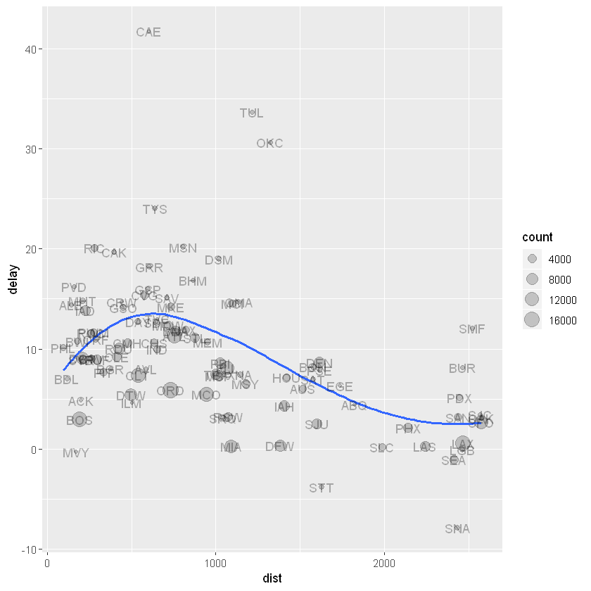

```r
#grafica de 2 variables continuas, grafica de puntos
#geom_text para poner etiquetas a los puntos
ggplot(data = delay, aes(x=dist, y=delay))+
  geom_point(aes(size = count), alpha=0.2)+
  geom_smooth(se=F)+
  geom_text(aes(label=dest), alpha=0.3)
```

**ejemplo con pipes %>%**

```r
#combinando pon pipes group by summarise y filter (con filter al final)
delay <- flights %>%
        group_by(dest)%>%
        summarise(count=n(),
                   dist = mean(distance, na.rm=T),
                   delay = mean(arr_delay, na.rm = T))%>%
        filter(delay, count>100, dest != "HNL")

head(delay)
```

| dest | count | dist | delay |
| --- | --- | --- | --- |
| ABQ | 254 | 1826.0000 | 4.381890 |
| ACK | 265 | 199.0000 | 4.852273 |
| ALB | 439 | 143.0000 | 14.397129 |
| ATL | 17215 | 757.1082 | 11.300113 |
| AUS | 2439 | 1514.2530 | 6.019909 |
| AVL | 275 | 583.5818 | 8.003831 |

```r
#combinando pon pipes group by summarise y filter (con filter al inicio)

not_cancelled <- flights%>%
  filter(!is.na(dep_delay), !is.na(arr_delay)) %>%
  group_by(year, month, day) %>%
  summarise(mean = mean(dep_delay))

head(not_cancelled)
```

| year | month | day | mean |
| --- | --- | --- | --- |
| 2013 | 1 | 1 | 11.435620 |
| 2013 | 1 | 2 | 13.677802 |
| 2013 | 1 | 3 | 10.907778 |
| 2013 | 1 | 4 | 8.965859 |
| 2013 | 1 | 5 | 5.732218 |
| 2013 | 1 | 6 | 7.145959 |

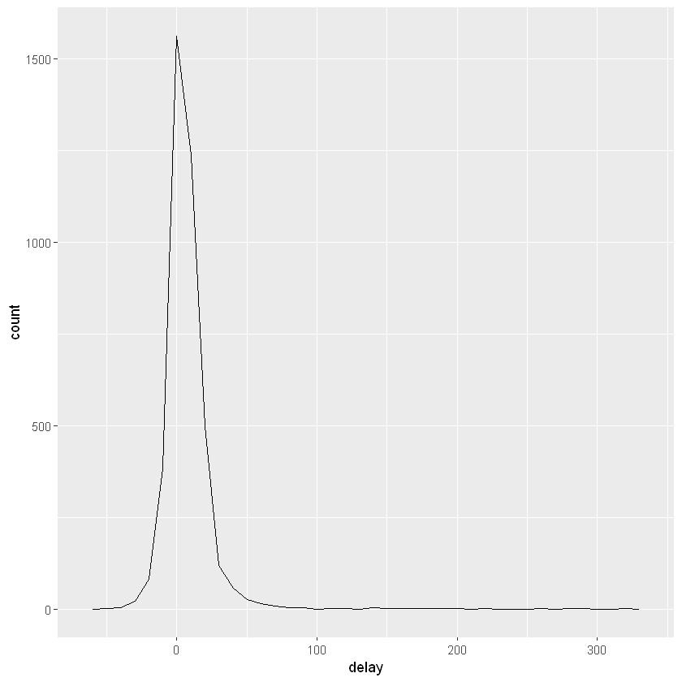

```r
#combiando pipes con ggplot

not_cancelled <- flights %>%
          filter(!is.na(dep_delay), !is.na(arr_delay))%>%
          group_by(tailnum) %>%
          summarise(delay=mean(arr_delay)) %>%
          ggplot(aes(x=delay))+
          geom_freqpoly(binwidth=10)
not_cancelled
```

```r
#medidas de centralizacion ***************************

not_cancelled <- flights %>%
          filter(!is.na(dep_delay), !is.na(arr_delay))%>%
            group_by(carrier) %>%
            summarise(
                mean=mean(arr_delay),
                mean2=mean(arr_delay[arr_delay>0]),
                median = median(arr_delay)
              )
not_cancelled
```

| carrier | mean | mean2 | median |
| --- | --- | --- | --- |
| 9E | 7.3796692 | 49.27271 | -7 |
| AA | 0.3642909 | 38.26555 | -9 |
| AS | -9.9308886 | 34.36508 | -17 |
| B6 | 9.4579733 | 40.00906 | -3 |
| DL | 1.6443409 | 37.74356 | -8 |
| EV | 15.7964311 | 48.26858 | -1 |
| F9 | 21.9207048 | 47.57908 | 6 |
| FL | 20.1159055 | 41.09446 | 5 |
| HA | -6.9152047 | 35.03093 | -13 |
| MQ | 10.7747334 | 37.85205 | -1 |
| OO | 11.9310345 | 60.60000 | -7 |
| UA | 3.5580111 | 36.65098 | -6 |
| US | 2.1295951 | 29.01157 | -6 |
| VX | 1.7644644 | 43.84708 | -9 |
| WN | 9.6491199 | 40.74755 | -3 |
| YV | 15.5569853 | 51.08140 | -2 |

```r
# medidas de dispersion **********************************

not_cancelled <- flights %>%
          filter(!is.na(dep_delay), !is.na(arr_delay))%>%
          group_by(carrier) %>%
          summarise(
            sd= sd(arr_delay),
            iqr = IQR(arr_delay),
            mad = mad(arr_delay)
          ) %>%
          arrange(desc(sd))
not_cancelled
```

| carrier | sd | iqr | mad |
| --- | --- | --- | --- |
| HA | 75.12942 | 30.50 | 22.2390 |
| F9 | 61.64600 | 40.00 | 26.6868 |
| FL | 54.08767 | 31.00 | 20.7564 |
| YV | 52.92223 | 40.25 | 25.2042 |
| 9E | 50.08678 | 36.00 | 23.7216 |
| VX | 49.96645 | 31.00 | 22.2390 |
| EV | 49.86147 | 40.00 | 23.7216 |
| OO | 48.58493 | 22.00 | 14.8260 |
| WN | 46.87770 | 30.00 | 20.7564 |
| DL | 44.40229 | 28.00 | 19.2738 |
| MQ | 43.17431 | 31.00 | 20.7564 |
| B6 | 42.84230 | 31.00 | 20.7564 |
| AA | 42.51618 | 29.00 | 20.7564 |
| UA | 40.98434 | 30.00 | 20.7564 |
| AS | 36.48263 | 34.00 | 25.2042 |
| US | 33.06695 | 23.00 | 16.3086 |

```r
#otras medidas de dispersion ********************************

not_cancelled <- flights %>%
          filter(!is.na(dep_delay), !is.na(arr_delay))%>%
          group_by(carrier) %>%
          summarise(
            first = min(arr_delay),
            q1 = quantile(arr_delay, 0.25),
            median = quantile(arr_delay, 0.5), #median()
            q3 = quantile(arr_delay, 0.75),
            last = max(arr_delay)
          )

not_cancelled
```

| carrier | first | q1 | median | q3 | last |
| --- | --- | --- | --- | --- | --- |
| 9E | -68 | -21.00 | -7 | 15.00 | 744 |
| AA | -75 | -21.00 | -9 | 8.00 | 1007 |
| AS | -74 | -32.00 | -17 | 2.00 | 198 |
| B6 | -71 | -14.00 | -3 | 17.00 | 497 |
| DL | -71 | -20.00 | -8 | 8.00 | 931 |
| EV | -62 | -14.00 | -1 | 26.00 | 577 |
| F9 | -47 | -9.00 | 6 | 31.00 | 834 |
| FL | -44 | -7.00 | 5 | 24.00 | 572 |
| HA | -70 | -27.75 | -13 | 2.75 | 1272 |
| MQ | -53 | -13.00 | -1 | 18.00 | 1127 |
| OO | -26 | -16.00 | -7 | 6.00 | 157 |
| UA | -75 | -18.00 | -6 | 12.00 | 455 |
| US | -70 | -15.00 | -6 | 8.00 | 492 |
| VX | -86 | -23.00 | -9 | 8.00 | 676 |
| WN | -58 | -15.00 | -3 | 15.00 | 453 |
| YV | -46 | -16.00 | -2 | 24.25 | 381 |

```r
#medidas de posicion ******************************************

not_cancelled <- flights %>%
          filter(!is.na(dep_delay), !is.na(arr_delay))%>%
          group_by(carrier) %>%
          summarise(
            first_dep = first(dep_time),
            second_dep = nth(dep_time,2),
            third_dep = nth(dep_time, 3),
            last_dep = last(dep_time)
          )

not_cancelled
```

| carrier | first_dep | second_dep | third_dep | last_dep |
| --- | --- | --- | --- | --- |
| 9E | 810 | 1451 | 1452 | 2159 |
| AA | 542 | 558 | 559 | 2140 |
| AS | 724 | 1808 | 722 | 1829 |
| B6 | 544 | 555 | 557 | 2349 |
| DL | 554 | 602 | 606 | 2121 |
| EV | 557 | 624 | 632 | 2211 |
| F9 | 833 | 1716 | 827 | 1720 |
| FL | 717 | 814 | 1021 | 2034 |
| HA | 857 | 909 | 914 | 959 |
| MQ | 600 | 602 | 608 | 2207 |
| OO | 1222 | 1424 | 1443 | 1751 |
| UA | 517 | 533 | 554 | 2233 |
| US | 622 | 627 | 629 | 2057 |
| VX | 658 | 729 | 859 | 2009 |
| WN | 629 | 754 | 852 | 2104 |
| YV | 1428 | 1551 | 1430 | 2000 |

```r
#min_rank: el menor valor toma el valor 1 (de un ord asc)

not_cancelled <- flights %>%
          filter(!is.na(dep_delay), !is.na(arr_delay))%>%
          group_by(carrier) %>%
          mutate(rank = min_rank(dep_time)) %>% #aqui hace un ranking por carrier
          filter(rank %in% range(rank))         #aqui filtro por el minino y max de cada carrier
                                                #range(rank) da el minimo y maximo y en este caso por carrier

head(not_cancelled,20)
```

| year | month | day | dep_time | sched_dep_time | dep_delay | arr_time | sched_arr_time | arr_delay | carrier | flight | tailnum | origin | dest | air_time | distance | hour | minute | time_hour | rank |
| --- | --- | --- | --- | --- | --- | --- | --- | --- | --- | --- | --- | --- | --- | --- | --- | --- | --- | --- | --- |
| 2013 | 1 | 9 | 641 | 900 | 1301 | 1242 | 1530 | 1272 | HA | 51 | N384HA | JFK | HNL | 640 | 4983 | 9 | 0 | 2013-01-09 09:00:00 | 1 |
| 2013 | 1 | 13 | 1 | 2249 | 72 | 108 | 2357 | 71 | B6 | 22 | N206JB | JFK | SYR | 41 | 209 | 22 | 49 | 2013-01-13 22:00:00 | 1 |
| 2013 | 1 | 16 | 2 | 2125 | 157 | 119 | 2250 | 149 | MQ | 4660 | N504MQ | LGA | BNA | 121 | 764 | 21 | 25 | 2013-01-16 21:00:00 | 1 |
| 2013 | 1 | 30 | 1222 | 1115 | 67 | 1402 | 1215 | 107 | OO | 8500 | N978SW | LGA | ORD | 132 | 733 | 11 | 15 | 2013-01-30 11:00:00 | 1 |
| 2013 | 1 | 31 | 1 | 2100 | 181 | 124 | 2225 | 179 | WN | 530 | N550WN | LGA | MDW | 127 | 725 | 21 | 0 | 2013-01-31 21:00:00 | 1 |
| 2013 | 10 | 30 | 2400 | 2359 | 1 | 327 | 337 | -10 | B6 | 839 | N661JB | JFK | BQN | 182 | 1576 | 23 | 59 | 2013-10-30 23:00:00 | 54027 |
| 2013 | 11 | 13 | 1 | 2359 | 2 | 442 | 440 | 2 | B6 | 1503 | N627JB | JFK | SJU | 194 | 1598 | 23 | 59 | 2013-11-13 23:00:00 | 1 |
| 2013 | 11 | 17 | 2357 | 1920 | 277 | 139 | 2111 | 268 | 9E | 2931 | N929XJ | JFK | PIT | 72 | 340 | 19 | 20 | 2013-11-17 19:00:00 | 17294 |
| 2013 | 11 | 25 | 651 | 705 | -14 | 1018 | 1017 | 1 | AS | 15 | N402AS | EWR | SEA | 364 | 2402 | 7 | 5 | 2013-11-25 07:00:00 | 1 |
| 2013 | 11 | 27 | 2400 | 2359 | 1 | 515 | 445 | 30 | B6 | 745 | N629JB | JFK | PSE | 230 | 1617 | 23 | 59 | 2013-11-27 23:00:00 | 54027 |
| 2013 | 12 | 5 | 2400 | 2359 | 1 | 427 | 440 | -13 | B6 | 1503 | N587JB | JFK | SJU | 182 | 1598 | 23 | 59 | 2013-12-05 23:00:00 | 54027 |
| 2013 | 12 | 9 | 2400 | 2359 | 1 | 432 | 440 | -8 | B6 | 1503 | N705JB | JFK | SJU | 195 | 1598 | 23 | 59 | 2013-12-09 23:00:00 | 54027 |
| 2013 | 12 | 9 | 2400 | 2250 | 70 | 59 | 2356 | 63 | B6 | 1816 | N187JB | JFK | SYR | 41 | 209 | 22 | 50 | 2013-12-09 22:00:00 | 54027 |
| 2013 | 12 | 13 | 2400 | 2359 | 1 | 432 | 440 | -8 | B6 | 1503 | N587JB | JFK | SJU | 192 | 1598 | 23 | 59 | 2013-12-13 23:00:00 | 54027 |
| 2013 | 12 | 16 | 1 | 2359 | 2 | 447 | 437 | 10 | B6 | 839 | N607JB | JFK | BQN | 202 | 1576 | 23 | 59 | 2013-12-16 23:00:00 | 1 |
| 2013 | 12 | 19 | 2400 | 2359 | 1 | 434 | 440 | -6 | B6 | 1503 | N561JB | JFK | SJU | 193 | 1598 | 23 | 59 | 2013-12-19 23:00:00 | 54027 |
| 2013 | 12 | 20 | 1 | 2359 | 2 | 430 | 440 | -10 | B6 | 1503 | N608JB | JFK | SJU | 182 | 1598 | 23 | 59 | 2013-12-20 23:00:00 | 1 |
| 2013 | 12 | 26 | 1 | 2359 | 2 | 437 | 440 | -3 | B6 | 1503 | N527JB | JFK | SJU | 197 | 1598 | 23 | 59 | 2013-12-26 23:00:00 | 1 |
| 2013 | 12 | 29 | 2400 | 1700 | 420 | 302 | 2025 | 397 | AA | 2379 | N3GMAA | LGA | MIA | 161 | 1096 | 17 | 0 | 2013-12-29 17:00:00 | 31946 |
| 2013 | 12 | 30 | 1 | 2359 | 2 | 441 | 437 | 4 | B6 | 839 | N508JB | JFK | BQN | 198 | 1576 | 23 | 59 | 2013-12-30 23:00:00 | 1 |

### Funciones de conteo

```r
#conteo n(),
#para conteo distinto usar: n_distinct

flights %>%
  group_by(dest) %>%
  summarise(
    count= n(), #planeado
    carriers = n_distinct(carrier),
    arrivals = sum(!is.na(arr_delay))#los que salieron
  ) %>%
  arrange(desc(carriers))
```

| dest | count | carriers | arrivals |
| --- | --- | --- | --- |
| ATL | 17215 | 7 | 16837 |
| BOS | 15508 | 7 | 15022 |
| CLT | 14064 | 7 | 13674 |
| ORD | 17283 | 7 | 16566 |
| TPA | 7466 | 7 | 7390 |
| AUS | 2439 | 6 | 2411 |
| DCA | 9705 | 6 | 9111 |
| DTW | 9384 | 6 | 9031 |
| IAD | 5700 | 6 | 5383 |
| MSP | 7185 | 6 | 6929 |
| MSY | 3799 | 6 | 3715 |
| PIT | 2875 | 6 | 2746 |
| STL | 4339 | 6 | 4142 |
| BNA | 6333 | 5 | 6084 |
| CLE | 4573 | 5 | 4394 |
| DEN | 7266 | 5 | 7169 |
| IND | 2077 | 5 | 1981 |
| LAS | 5997 | 5 | 5952 |
| LAX | 16174 | 5 | 16026 |
| PBI | 6554 | 5 | 6487 |
| PHL | 1632 | 5 | 1541 |
| PHX | 4656 | 5 | 4606 |
| RDU | 8163 | 5 | 7770 |
| SEA | 3923 | 5 | 3885 |
| SFO | 13331 | 5 | 13173 |
| BUF | 4681 | 4 | 4570 |
| BWI | 1781 | 4 | 1687 |
| CHS | 2884 | 4 | 2759 |
| CVG | 3941 | 4 | 3725 |
| DFW | 8738 | 4 | 8388 |
| ... | ... | ... | ... |
| XNA | 1036 | 2 | 992 |
| ABQ | 254 | 1 | 254 |
| ACK | 265 | 1 | 264 |
| ALB | 439 | 1 | 418 |
| ANC | 8 | 1 | 8 |
| BHM | 297 | 1 | 269 |
| BUR | 371 | 1 | 370 |
| BZN | 36 | 1 | 35 |
| CAK | 864 | 1 | 842 |
| CHO | 52 | 1 | 46 |
| CRW | 138 | 1 | 134 |
| EYW | 17 | 1 | 17 |
| HDN | 15 | 1 | 14 |
| ILM | 110 | 1 | 107 |
| LEX | 1 | 1 | 1 |
| LGA | 1 | 1 | 0 |
| LGB | 668 | 1 | 661 |
| MDW | 4113 | 1 | 4025 |
| MTJ | 15 | 1 | 14 |
| MYR | 59 | 1 | 58 |
| OAK | 312 | 1 | 309 |
| OKC | 346 | 1 | 315 |
| PSE | 365 | 1 | 358 |
| PSP | 19 | 1 | 18 |
| PVD | 376 | 1 | 358 |
| SAV | 804 | 1 | 749 |
| SBN | 10 | 1 | 10 |
| SMF | 284 | 1 | 282 |
| SNA | 825 | 1 | 812 |
| TUL | 315 | 1 | 294 |

```r
#Se puede hacer agrupacion sin summarise directamente con count() para hacer recuentos
not_cancelled %>% count(dest)
```

| carrier | dest | n |
| --- | --- | --- |
| 9E | PIT | 1 |
| 9E | SYR | 1 |
| AA | MIA | 1 |
| AA | ORD | 2 |
| AS | SEA | 2 |
| B6 | BOS | 1 |
| B6 | BQN | 11 |
| B6 | BTV | 1 |
| B6 | DEN | 1 |
| B6 | FLL | 2 |
| B6 | PSE | 10 |
| B6 | PWM | 1 |
| B6 | ROC | 1 |
| B6 | SFO | 1 |
| B6 | SJU | 10 |
| B6 | SYR | 3 |
| B6 | TPA | 1 |
| DL | ATL | 3 |
| DL | BOS | 1 |
| DL | LAS | 2 |
| DL | MIA | 1 |
| EV | DCA | 1 |
| EV | TYS | 1 |
| F9 | DEN | 2 |
| FL | CAK | 2 |
| HA | HNL | 2 |
| MQ | BNA | 2 |
| MQ | ORF | 1 |
| OO | CLE | 1 |
| OO | ORD | 1 |
| UA | BOS | 1 |
| UA | BQN | 1 |
| US | DCA | 2 |
| VX | LAX | 1 |
| VX | SFO | 1 |
| WN | MDW | 2 |
| WN | MKE | 1 |
| YV | IAD | 2 |

```r
#Opcionalmente, puede proporcionar una variable de peso.
#Por ejemplo, podría usar esto para "contar" (suma) el número total de millas que voló un avión

not_cancelled %>%
  count(tailnum, wt = distance)
```

| carrier | tailnum | n |
| --- | --- | --- |
| 9E | N917XJ | 198 |
| 9E | N929XJ | 340 |
| AA | N3GMAA | 1096 |
| AA | N544AA | 733 |
| AA | N546AA | 733 |
| AS | N402AS | 2402 |
| AS | N516AS | 2402 |
| B6 | N187JB | 209 |
| B6 | N206JB | 209 |
| B6 | N216JB | 273 |
| B6 | N228JB | 264 |
| B6 | N328JB | 266 |
| B6 | N334JB | 209 |
| B6 | N373JB | 187 |
| B6 | N503JB | 3174 |
| B6 | N507JB | 1576 |
| B6 | N508JB | 3193 |
| B6 | N517JB | 1617 |
| B6 | N523JB | 1576 |
| B6 | N527JB | 3215 |
| B6 | N552JB | 1617 |
| B6 | N559JB | 1576 |
| B6 | N561JB | 1598 |
| B6 | N586JB | 1617 |
| B6 | N587JB | 3196 |
| B6 | N597JB | 1005 |
| B6 | N606JB | 1576 |
| B6 | N607JB | 2652 |
| B6 | N608JB | 1598 |
| B6 | N612JB | 1617 |
| ... | ... | ... |
| DL | N3766 | 2248 |
| DL | N376DA | 2248 |
| DL | N675DL | 762 |
| DL | N906DE | 1096 |
| DL | N910DE | 762 |
| DL | N945DL | 762 |
| EV | N22971 | 199 |
| EV | N27200 | 631 |
| F9 | N203FR | 1620 |
| F9 | N218FR | 1620 |
| FL | N923AT | 397 |
| FL | N950AT | 397 |
| HA | N384HA | 4983 |
| HA | N389HA | 4983 |
| MQ | N500MQ | 764 |
| MQ | N504MQ | 764 |
| MQ | N606MQ | 290 |
| OO | N790SK | 419 |
| OO | N978SW | 733 |
| UA | N33203 | 200 |
| UA | N79521 | 1585 |
| US | N721UW | 214 |
| US | N738US | 214 |
| VX | N628VA | 2475 |
| VX | N631VA | 2586 |
| WN | N231WN | 725 |
| WN | N550WN | 725 |
| WN | N7734H | 738 |
| YV | N515MJ | 229 |
| YV | N519LR | 229 |

```r
#suma con valores logicos

not_cancelled %>%
  group_by(year, month, day) %>%
  summarise(n_nearly = sum(dep_time<500))
```

| year | month | day | n_nearly |
| --- | --- | --- | --- |
| 2013 | 1 | 9 | 0 |
| 2013 | 1 | 13 | 1 |
| 2013 | 1 | 16 | 1 |
| 2013 | 1 | 30 | 0 |
| 2013 | 1 | 31 | 1 |
| 2013 | 2 | 7 | 0 |
| 2013 | 2 | 10 | 0 |
| 2013 | 2 | 11 | 1 |
| 2013 | 2 | 23 | 0 |
| 2013 | 2 | 24 | 1 |
| 2013 | 2 | 27 | 0 |
| 2013 | 3 | 8 | 2 |
| 2013 | 3 | 15 | 0 |
| 2013 | 3 | 18 | 2 |
| 2013 | 3 | 19 | 1 |
| 2013 | 3 | 22 | 0 |
| 2013 | 3 | 25 | 0 |
| 2013 | 4 | 2 | 0 |
| 2013 | 4 | 4 | 0 |
| 2013 | 4 | 5 | 1 |
| 2013 | 4 | 10 | 1 |
| 2013 | 4 | 18 | 0 |
| 2013 | 4 | 20 | 0 |
| 2013 | 5 | 21 | 0 |
| 2013 | 5 | 22 | 2 |
| 2013 | 5 | 23 | 1 |
| 2013 | 5 | 25 | 1 |
| 2013 | 6 | 7 | 0 |
| 2013 | 6 | 17 | 1 |
| 2013 | 6 | 20 | 1 |
| ... | ... | ... | ... |
| 2013 | 7 | 10 | 0 |
| 2013 | 7 | 13 | 0 |
| 2013 | 7 | 17 | 1 |
| 2013 | 7 | 22 | 1 |
| 2013 | 7 | 27 | 1 |
| 2013 | 7 | 28 | 1 |
| 2013 | 8 | 3 | 1 |
| 2013 | 8 | 9 | 0 |
| 2013 | 8 | 10 | 0 |
| 2013 | 8 | 15 | 1 |
| 2013 | 8 | 19 | 1 |
| 2013 | 8 | 20 | 0 |
| 2013 | 8 | 28 | 0 |
| 2013 | 9 | 2 | 0 |
| 2013 | 9 | 12 | 0 |
| 2013 | 9 | 13 | 1 |
| 2013 | 10 | 30 | 0 |
| 2013 | 11 | 13 | 1 |
| 2013 | 11 | 17 | 0 |
| 2013 | 11 | 25 | 0 |
| 2013 | 11 | 27 | 0 |
| 2013 | 12 | 5 | 0 |
| 2013 | 12 | 9 | 0 |
| 2013 | 12 | 13 | 0 |
| 2013 | 12 | 16 | 1 |
| 2013 | 12 | 19 | 0 |
| 2013 | 12 | 20 | 1 |
| 2013 | 12 | 26 | 1 |
| 2013 | 12 | 29 | 0 |
| 2013 | 12 | 30 | 1 |

```r
not_cancelled %>%
  group_by(year, month, day) %>%
  summarise(hour_perc =  mean(arr_delay>60))
```

| year | month | day | hour_perc |
| --- | --- | --- | --- |
| 2013 | 1 | 9 | 1.0 |
| 2013 | 1 | 13 | 1.0 |
| 2013 | 1 | 16 | 1.0 |
| 2013 | 1 | 30 | 1.0 |
| 2013 | 1 | 31 | 1.0 |
| 2013 | 2 | 7 | 0.0 |
| 2013 | 2 | 10 | 1.0 |
| 2013 | 2 | 11 | 1.0 |
| 2013 | 2 | 23 | 1.0 |
| 2013 | 2 | 24 | 0.5 |
| 2013 | 2 | 27 | 1.0 |
| 2013 | 3 | 8 | 0.5 |
| 2013 | 3 | 15 | 0.0 |
| 2013 | 3 | 18 | 1.0 |
| 2013 | 3 | 19 | 1.0 |
| 2013 | 3 | 22 | 0.0 |
| 2013 | 3 | 25 | 0.0 |
| 2013 | 4 | 2 | 0.0 |
| 2013 | 4 | 4 | 0.0 |
| 2013 | 4 | 5 | 0.0 |
| 2013 | 4 | 10 | 1.0 |
| 2013 | 4 | 18 | 1.0 |
| 2013 | 4 | 20 | 0.0 |
| 2013 | 5 | 21 | 0.0 |
| 2013 | 5 | 22 | 1.0 |
| 2013 | 5 | 23 | 1.0 |
| 2013 | 5 | 25 | 0.0 |
| 2013 | 6 | 7 | 1.0 |
| 2013 | 6 | 17 | 1.0 |
| 2013 | 6 | 20 | 0.0 |
| ... | ... | ... | ... |
| 2013 | 7 | 10 | 1.0000000 |
| 2013 | 7 | 13 | 1.0000000 |
| 2013 | 7 | 17 | 1.0000000 |
| 2013 | 7 | 22 | 1.0000000 |
| 2013 | 7 | 27 | 0.0000000 |
| 2013 | 7 | 28 | 0.3333333 |
| 2013 | 8 | 3 | 1.0000000 |
| 2013 | 8 | 9 | 1.0000000 |
| 2013 | 8 | 10 | 1.0000000 |
| 2013 | 8 | 15 | 0.0000000 |
| 2013 | 8 | 19 | 0.0000000 |
| 2013 | 8 | 20 | 0.0000000 |
| 2013 | 8 | 28 | 1.0000000 |
| 2013 | 9 | 2 | 0.0000000 |
| 2013 | 9 | 12 | 1.0000000 |
| 2013 | 9 | 13 | 1.0000000 |
| 2013 | 10 | 30 | 0.0000000 |
| 2013 | 11 | 13 | 0.0000000 |
| 2013 | 11 | 17 | 1.0000000 |
| 2013 | 11 | 25 | 0.0000000 |
| 2013 | 11 | 27 | 0.0000000 |
| 2013 | 12 | 5 | 0.0000000 |
| 2013 | 12 | 9 | 0.5000000 |
| 2013 | 12 | 13 | 0.0000000 |
| 2013 | 12 | 16 | 0.0000000 |
| 2013 | 12 | 19 | 0.0000000 |
| 2013 | 12 | 20 | 0.0000000 |
| 2013 | 12 | 26 | 0.0000000 |
| 2013 | 12 | 29 | 1.0000000 |
| 2013 | 12 | 30 | 0.0000000 |

### Agrupacion por multiples variables

Cuando agrupa por múltiples variables, cada resumen despega un nivel de la agrupación. Eso facilita la acumulación progresiva de un conjunto de datos

```r
daily = group_by(flights, year, month, day)
```

```r
(per_day <- summarise(daily, n_fl=n()))
```

| year | month | day | n_fl |
| --- | --- | --- | --- |
| 2013 | 1 | 1 | 842 |
| 2013 | 1 | 2 | 943 |
| 2013 | 1 | 3 | 914 |
| 2013 | 1 | 4 | 915 |
| 2013 | 1 | 5 | 720 |
| 2013 | 1 | 6 | 832 |
| 2013 | 1 | 7 | 933 |
| 2013 | 1 | 8 | 899 |
| 2013 | 1 | 9 | 902 |
| 2013 | 1 | 10 | 932 |
| 2013 | 1 | 11 | 930 |
| 2013 | 1 | 12 | 690 |
| 2013 | 1 | 13 | 828 |
| 2013 | 1 | 14 | 928 |
| 2013 | 1 | 15 | 894 |
| 2013 | 1 | 16 | 901 |
| 2013 | 1 | 17 | 927 |
| 2013 | 1 | 18 | 924 |
| 2013 | 1 | 19 | 674 |
| 2013 | 1 | 20 | 786 |
| 2013 | 1 | 21 | 912 |
| 2013 | 1 | 22 | 890 |
| 2013 | 1 | 23 | 897 |
| 2013 | 1 | 24 | 925 |
| 2013 | 1 | 25 | 922 |
| 2013 | 1 | 26 | 680 |
| 2013 | 1 | 27 | 823 |
| 2013 | 1 | 28 | 923 |
| 2013 | 1 | 29 | 890 |
| 2013 | 1 | 30 | 900 |
| ... | ... | ... | ... |
| 2013 | 12 | 2 | 1004 |
| 2013 | 12 | 3 | 973 |
| 2013 | 12 | 4 | 958 |
| 2013 | 12 | 5 | 969 |
| 2013 | 12 | 6 | 970 |
| 2013 | 12 | 7 | 691 |
| 2013 | 12 | 8 | 875 |
| 2013 | 12 | 9 | 962 |
| 2013 | 12 | 10 | 943 |
| 2013 | 12 | 11 | 954 |
| 2013 | 12 | 12 | 968 |
| 2013 | 12 | 13 | 970 |
| 2013 | 12 | 14 | 692 |
| 2013 | 12 | 15 | 880 |
| 2013 | 12 | 16 | 964 |
| 2013 | 12 | 17 | 949 |
| 2013 | 12 | 18 | 956 |
| 2013 | 12 | 19 | 974 |
| 2013 | 12 | 20 | 980 |
| 2013 | 12 | 21 | 811 |
| 2013 | 12 | 22 | 895 |
| 2013 | 12 | 23 | 985 |
| 2013 | 12 | 24 | 761 |
| 2013 | 12 | 25 | 719 |
| 2013 | 12 | 26 | 936 |
| 2013 | 12 | 27 | 963 |
| 2013 | 12 | 28 | 814 |
| 2013 | 12 | 29 | 888 |
| 2013 | 12 | 30 | 968 |
| 2013 | 12 | 31 | 776 |

```r
(per_month <- summarise(per_day, n_fl = sum(n_fl)))
```

| year | month | n_fl |
| --- | --- | --- |
| 2013 | 1 | 27004 |
| 2013 | 2 | 24951 |
| 2013 | 3 | 28834 |
| 2013 | 4 | 28330 |
| 2013 | 5 | 28796 |
| 2013 | 6 | 28243 |
| 2013 | 7 | 29425 |
| 2013 | 8 | 29327 |
| 2013 | 9 | 27574 |
| 2013 | 10 | 28889 |
| 2013 | 11 | 27268 |
| 2013 | 12 | 28135 |

```r
(per_year <- summarise(per_month, n_fl = sum(n_fl)))
```

| year | n_fl |
| --- | --- |
| 2013 | 336776 |

```r
business <- group_by(flights, carrier, dest, origin)

summarise(business, n_fl = n()) %>%
  summarise(n_fl = sum(n_fl)) %>%  #se come un nivel (origin)
  summarise(n_fl = sum(n_fl))  #se come un nivel (dest)
```

| carrier | n_fl |
| --- | --- |
| 9E | 18460 |
| AA | 32729 |
| AS | 714 |
| B6 | 54635 |
| DL | 48110 |
| EV | 54173 |
| F9 | 685 |
| FL | 3260 |
| HA | 342 |
| MQ | 26397 |
| OO | 32 |
| UA | 58665 |
| US | 20536 |
| VX | 5162 |
| WN | 12275 |
| YV | 601 |

```r
# lo anterior es igual a:

group_by(flights, carrier) %>%
  summarise(n_fl=n())
```

| carrier | n_fl |
| --- | --- |
| 9E | 18460 |
| AA | 32729 |
| AS | 714 |
| B6 | 54635 |
| DL | 48110 |
| EV | 54173 |
| F9 | 685 |
| FL | 3260 |
| HA | 342 |
| MQ | 26397 |
| OO | 32 |
| UA | 58665 |
| US | 20536 |
| VX | 5162 |
| WN | 12275 |
| YV | 601 |

### DESAGRUPAR

```r
daily = group_by(flights, year, month, day)

daily %>%
  ungroup() %>% #hizo la desagrupacion por fechas que hice
  summarise(n_fl=n()) #calcula sobre toda la base datos
```

| n_fl |
| --- |
| 336776 |

```r
business <- group_by(flights, carrier, dest, origin)

business %>%
  ungroup() %>%
  summarise(n_fl=n())
```

| n_fl |
| --- |
| 336776 |

```r
business <- group_by(flights, carrier, dest, origin)

summarise(business, n_fl = n()) %>%
  summarise(n_fl = sum(n_fl)) %>% #se como un nivel (origin)
  ungroup() %>% #retorna una base datos
  summarise(n_fl = sum(n_fl)) #el resumen es sobre la base datos, no de una agrupacion
```

| n_fl |
| --- |
| 336776 |